# Тестирование статистических гипотез

## Тестирование гипотез

- Стандартное нормальное распределение
- Как устроено тестирование гипотез
- t-статистика
- Применение t-теста
- Статистическая значимость

## Стандартное нормальное распределение

## Стандартизация (Z-преобразование)

Стандартизованная величина (Z-оценка) — показывает, на сколько стандартных отклонений значение отличается от среднего

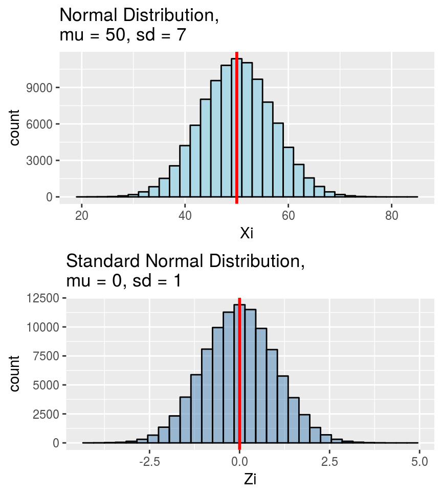

\[z_i=\frac{x_i - \bar{x}}{SD}\]

После **стандартизации** получается стандартное нормальное распределение

**После стандартизации всегда**:

- среднее \(\mu = 0\)
- стандартное отклонение \(\sigma = 1\)

Для стандартного нормального распределения легко можно посчитать вероятность (площадь под кривой)

## Вероятности — это площади под кривой распределения случайной величины.

Вся площадь под кривой распределения будет равна 1 (суммарная вероятность всех возможных значений равна 1)

Мы не можем узнать вероятность конкретного значения, т.к. конкретное значение — это точка, а под точкой нет площади.

Зато, мы можем узнать вероятность того, что случайная величина, взятая из данного распределения, попадет в конкретный диапазон значений…

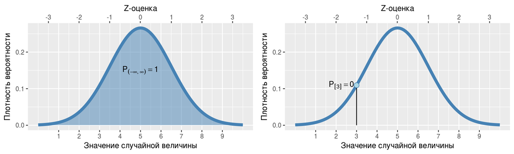

## Интергрирование вероятностей

Внимание! Мы умеем интегрировать только "влево" от заданного значения, т.е. мы можем непосредственно вычислить только вероятность того, что случайное значение окажется **меньше** заданного.

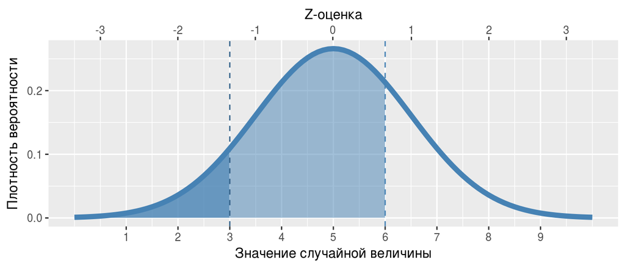

Поскольку вся площадь под кривой вероятностей равна 1, то вероятность оказаться **больше** заданного значения — это 1 минус вероятность оказаться **меньше**.

## Пример: Размеры улиток

В выборке улиток средний диаметр раковины 5 см со стандартным отклонением 1.5 см.

- Какова вероятность того, что случайно выбранная улитка окажется **меньше 3 см**?
- Какова вероятность того, что случайно выбранная улитка окажется **больше 6 см**?
- Какова доля улиток с размером раковины **в пределах 3–6 см**?

tres caracoles by Alberto Villen on Freeimages.com

## Вероятность встретить значение меньше заданного размера

В выборке улиток средний диаметр раковины 5 см со стандартным отклонением 1.5 см.

### Какова вероятность того, что случайно выбранная улитка окажется **меньше 3 см**?

```r
Z_1 <- (3 - 5) / 1.5
pnorm(Z_1)
```

```
## [1] 0.0912
```

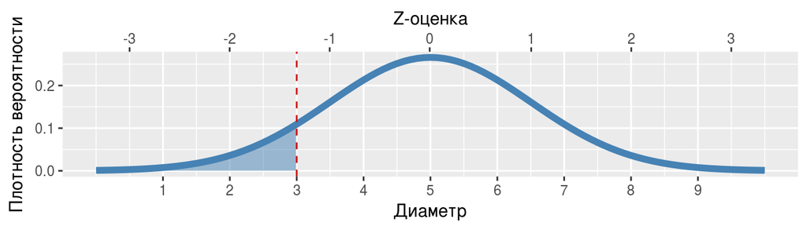

## Вероятность встретить значение больше заданного размера

В выборке улиток средний диаметр раковины 5 см со стандартным отклонением 1.5 см.

### Какова вероятность того, что случайно выбранная улитка окажется **больше 6 см**?

Мы умеем интегрировать только влево от выбранного значения, поэтому

- выясняем вероятность встретить значение меньше заданного \(p\)
- находим комплементарную вероятность \(1 - p\)

```r
Z_2 <- (6 - 5) / 1.5
1 - pnorm(Z_2)
```

```
## [1] 0.252
```

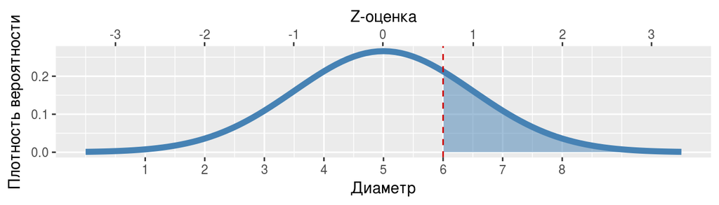

## Вероятность встретить значение в заданных пределах

В выборке улиток средний диаметр раковины 5 см со стандартным отклонением 1.5 см.

### Какова доля улиток с размером раковины **в пределах 3–6 см**?

```r
pnorm(Z_2) - pnorm(Z_1)
```

```
## [1] 0.656
```

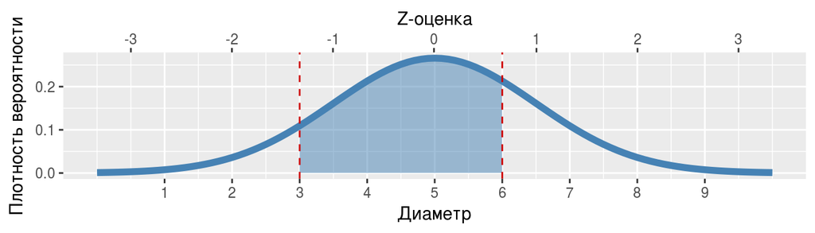

## Задача:

Предположим, что средний рост мужчин в России 176 см со стандартным отклонением 7 см. В пилоты берут только с ростом от 160 до 190 см (по приказу Минтранса).

- Какова вероятность того, что случайно выбранный мужчина окажется **ниже 160 см**?
- Какова вероятность того, что случайно выбранный мужчина окажется **больше 190 см**?
- Какова доля мужчин, не подходящих по росту в пилоты, т.е. **меньше 160 и больше 190 см**?

## Решение

Предположим, что средний рост мужчин в России 176 см со стандартным отклонением 7 см. В пилоты берут только с ростом от 160 до 190 см (по приказу Минтранса).

### Какова вероятность того, что случайно выбранный мужчина окажется **ниже 160 см**?

```r
Z_short <- (160 - 176) / 7
pnorm(Z_short)
```

```
## [1] 0.0111
```

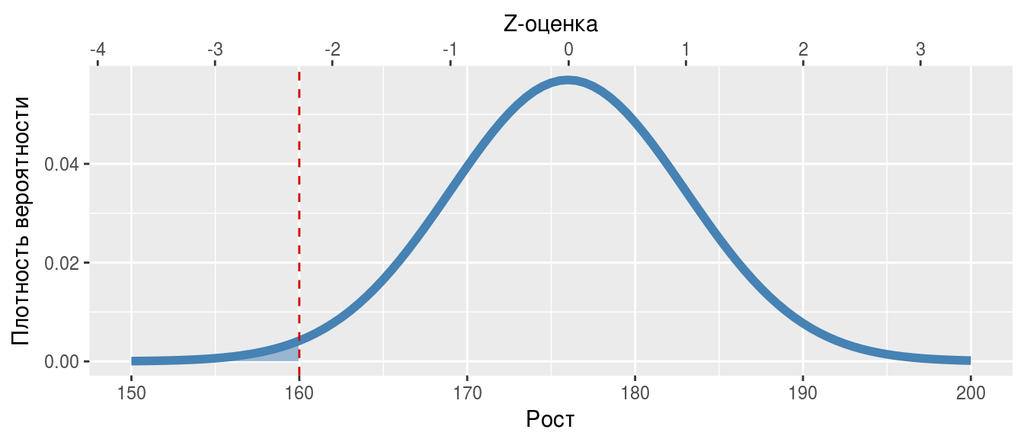

## Решение

Предположим, что средний рост мужчин в России 176 см со стандартным отклонением 7 см. В пилоты берут только с ростом от 160 до 190 см (по приказу Минтранса).

### Какова вероятность того, что случайно выбранный мужчина окажется **больше 190 см**?

```r
Z_tall <- (190 - 176) / 7
1 - pnorm(Z_tall)
```

```
## [1] 0.0228
```

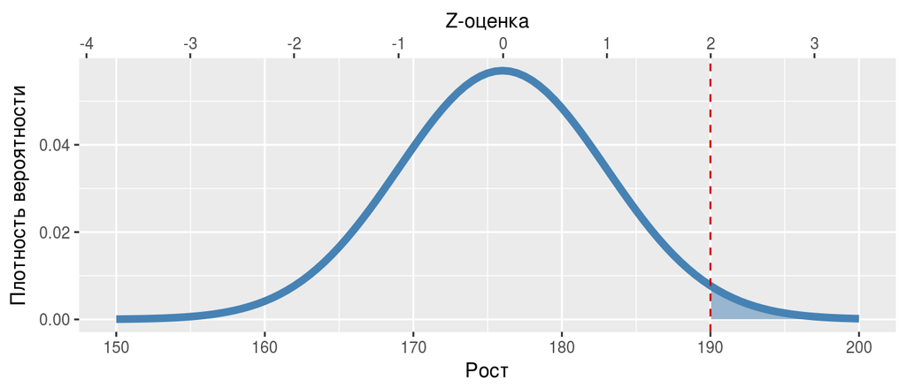

## Решение

Предположим, что средний рост мужчин в России 176 см со стандартным отклонением 7 см. В пилоты берут только с ростом от 160 до 190 см (по приказу Минтранса).

### Какова доля мужчин, не подходящих по росту в пилоты, т.е. **меньше 160 и больше 190 см**?

```r
pnorm(Z_short) + (1 - pnorm(Z_tall))
```

```
## [1] 0.0339
```

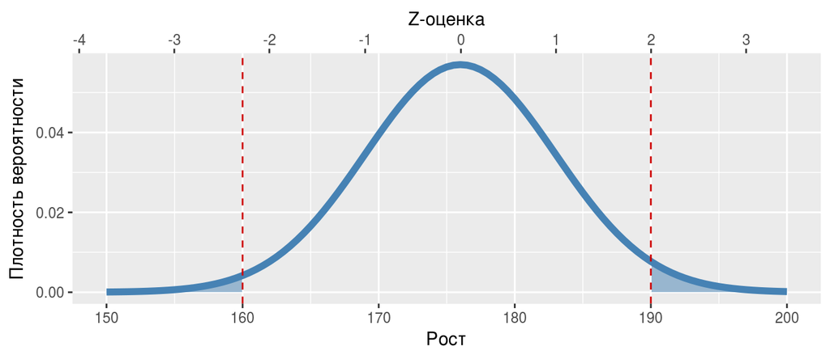

## Как устроено тестирование гипотез

## Сравнение выборок

Различия между выборками не всегда видны невооружённым глазом.

tres caracoles by Alberto Villen on Freeimages.com

## Гипотезы: нулевая и альтернативная

Первый шаг в сравнении – формулировка нулевой гипотезы.

Вместе с нулевой гипотезой рождается альтернативная гипотеза.

tres caracoles by Alberto Villen on Freeimages.com

- Нулевая гипотеза \(H_0\) чаще всего формулируется как **отсутствие различий** между сравниваемыми объектами. Например: Улитки из обеих популяций одинакового размера
- Альтернативная гипотеза \(H_A\) формулируется как **присутствие различий**, она обратна нулевой гипотезе, т.е. включает все остальные случаи. Например: Улитки из обеих популяций разного размера.

## Нулевая и альтернативная гипотезы — это "два мира"

Вне зависимости от нас, реальность может находиться в одном из двух состояний:

- \(H_0\) верна, улитки одинаковы
- \(H_0\) неверна, улитки различаются

| \(H_0\) верна | \(H_0\) неверна |
| --- | --- |

После статистического теста мы принимаем решение о том, принять или отвергнуть \(H_0\). Но это решение не обязательно окажется верным. Возможно четыре исхода:

В мире где улитки одинаковы (\(H_0\) верна) мы можем:  
- принять \(H_0\) (верное решение),  
- отвергнуть \(H_0\) (ошибка).

Аналогично, в мире где улитки различаются (\(H_A\) верна), мы можем:  
- принять \(H_0\) (ошибка),  
- либо отвергнуть \(H_0\) (верное решение).

## Верные и неверные решения

**Ошибка I рода: нашли то, чего нет**

**Ошибка II рода: не нашли то, что было**

|  | \(H_0\) верна | \(H_0\) неверна |
| --- | --- | --- |
| Отклонить H0 | Ошибка I рода с вероятностью α Ложно-положительный результат | Верно |
| Сохранить H0 | Верно | Ошибка II рода с вероятностью β Ложно-отрицательный результат |

## Тестирование гипотез: Тестовые статистики

Гипотезы выражаются математически в виде тестовых статистик.

По нашим реальным данным мы вычисляем **эмпирическое значение тестовой статистики**.

Дальше мы должны ответить на вопрос:

### Насколько вероятно получить *такое или более экстремальное* эмпирическое значение, если верна нулевая гипотеза \(H_0\)?

Ответить на этот вопрос можно, построив **теоретическое распределение тестовой статистики** для случая, когда верна \(H_0\)

## Пример тестовой статистики: Z-тест для разницы средних (для больших выборок)

\(H_0: \bar x_1 - \bar x_2 = 0\), \(H_A: \bar x_1 - \bar x_2 \ne 0\)

\[Z = \frac{\bar x_1 - \bar x_2}{SE}\] \(\bar x_1 - \bar x_2\) — разница средних; \(SE = SD / \sqrt{n}\) — стандартная ошибка

**Для больших выборок** (больше 100) выборочная оценка стандартизованной разницы средних значений распределена практически нормально. Поэтому для тестирования гипотез можно использовать стандартное нормальное распределение.

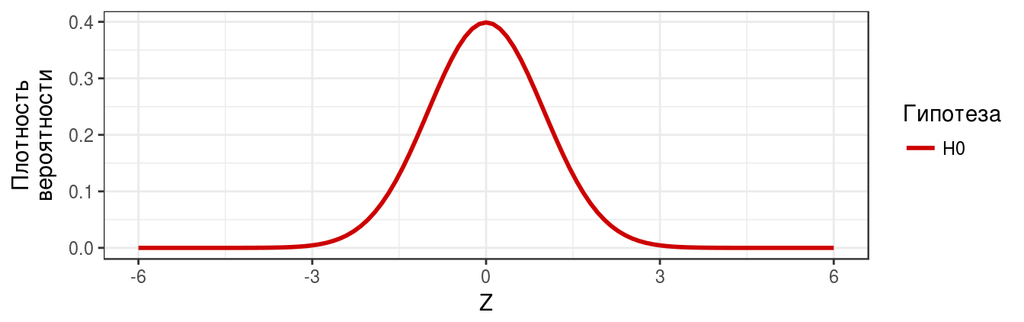

Одни значения тестовой статистики будут встречаться часто, другие — редко.

## Доверительная вероятность (p-value)

Площадь под любым участком этой кривой соответствует вероятности получения значений тестовой статистики в этом интервале (при условии справедливости \(H_0\)).

Вероятность получить *такое или более экстремальное* эмпирическое значение (при условии справедливости \(H_0\)) — это **доверительная вероятность** (p-value)

Обычно нам все равно, в какой из хвостов теоретического распределения попадает наше значение тестовой статистики, поэтому мы обычно учитываем оба

\[P = P(z_{observed} < |z_0|~и~z_{observed} > |z_0|)\]

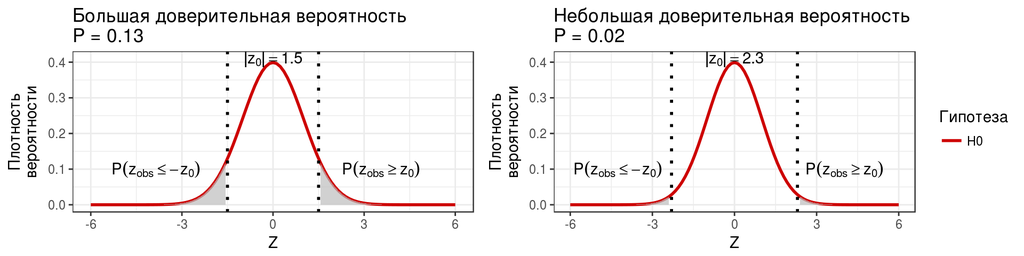

## Уровень значимости \(\alpha\)

Считается, что если вероятность получить конкретное значение тестовой статистики в условиях справедливой \(H_0\) достаточно мала, то такую нулевую гипотезу можно отвергнуть.

**Уровень значимости \(\alpha\) — это вероятность ошибочно отвергнуть справедливую нулевую гипотезу**. Т.е. это вероятность найти различия там, где их нет (**вероятность ошибки I рода**). Обычно выбирают уровень значимости \(\alpha = 0.05\), реже \(0.01\)

Для z-теста \(\alpha\) — это вероятность ошибочно сделать вывод о том, что средние выборок различаются **при условии, что эти выборки получены из одной генеральной совокупности**.

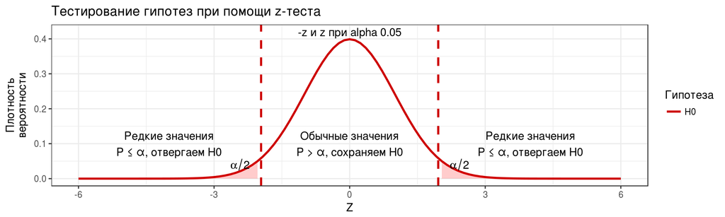

## Тестирование гипотез: Как принять решение?

### Алгоритм действий

1. Для конкретных данных получаем значение тестовой статистики
2. Сравниваем его с теоретическим распределением (распределением при условии, что \(H_0\) верна) и находим вероятность найти более экстремальное значение тестовой статистики
3. Решаем, отвергнуть ли \(H_0\):
   - Если \(P \le \alpha\), отвергаем \(H_0\)
   - Если \(P > \alpha\), сохраняем \(H_0\)

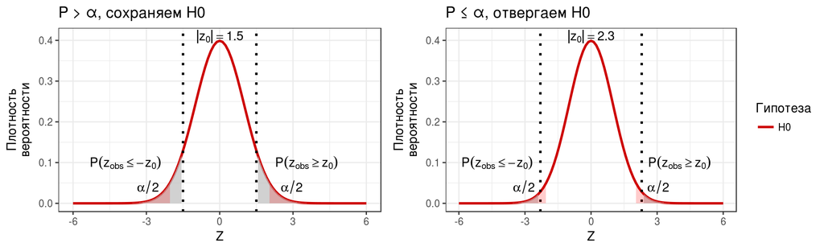

## Доверительная вероятность (p-value).

### Ещё раз, другими словами

Допустим, мы сравнили выборки и получили \(р = 0.03\)

\(p = 0.03\) — **это не значит**, что \(H_0\) верна с вероятностью 3%!

\(p = 0.03\) — **это значит**, что если выборки одинаковы, а \(H_0\) верна, шанс получить результат, который мы получили составляет 3%.

Уже мы сами решаем, кажется ли нам такая вероятность приемлемой (сравниваем с выбранным уровнем значимости \(\alpha\))

## t-статистика

## Z-тест непригоден для проверки равенства средних в малых выборках

\(H_0: \bar x_1 - \bar x_2 = 0\), \(H_A: \bar x_1 - \bar x_2 \ne 0\)

Для малых выборок нельзя использовать Z-тест для проверки \(H_0: \bar x_1 - \bar x_2 = 0\), поскольку в этом случае стандартизованная разница средних уже не подчиняется нормальному распределению

## t-статиктика Стьюдента (t-критерий)

Гипотезы: \(H_0: \bar{x}_1 = \bar{x}_2\), \(H_A: \bar{x}_1 \ne \bar{x}_2\)

Двухвыборочный тест Стьюдента (Student, 1908) используется для проверки значимости различий между средними значениями двух нормально распределенных величин.

\[t=\frac{\bar{x}_1 - \bar{x}_2}{SE}\]

Условия применимости:

- Выборки случайны и независимы друг от друга
- Величины нормально распределены
- **Дисперсии в группах одинаковы**
- \(\bar x_1 - \bar x_2\) — это разность между двумя средними значениями
- \(SE = \sqrt{\frac{s_1^2(n_1-1) +s_2^2(n_2-1)}{n_1+n_2-2}\Big(\frac{1}{n_1} + \frac{1}{n_2}\Big)}\) — Обобщенное стандартная ошибка разности двух средних
- \(df = (n_1 - 1) + (n_2 - 1) = n_1 + n_2 - 2\) — число степеней свободы

## t-тест Уэлча — это модификация теста Стьюдента **для случая разных дисперсий**

\[t=\frac{\bar{x}_1 - \bar{x}_2}{SE}\]

Условия применимости:

- Выборки случайны и независимы друг от друга
- Величины нормально распределены

\[SE = \sqrt{\frac {s_1^2} {n_1} + \frac {s_2^2} {n_2}}\]

Приблизительное число степеней свободы рассчитывается по уравнению Уэлча-Саттеруэйта

\[df_{ Welch–Satterthwaite} \approx \frac {\Big(\frac{s^2_1}{n_1} + \frac{s^2_2}{n_2}\Big)^2} {\frac {s_1^4} {n^2_1 \cdot df_1} + \frac {s_2^4} {n^2_2 \cdot df_1}}\]

## t-распределение — распределение разницы средних для выборок из одной совокупности

t-статистика подчиняется t-распределению.

Иными словами, если много раз взять выборки **из одной** совокупности (т.е. при условии, что \(H_0\) верна) и посчитать между ними разницу, то она будет подчиняться t-распределению.

Форма t-распределения зависит только от одного параметра — числа степеней свободы \(df = n_1 + n_2 - 2\)

При больших объемах выборок форма t-распределения приближается к нормальному

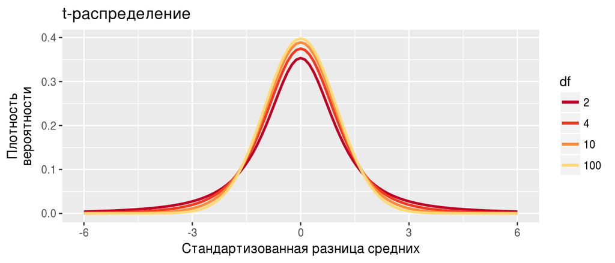

## Уровень значимости \(\alpha\)

Для t-теста \(\alpha\) — это вероятность ошибочно сделать вывод о том, что средние выборок различаются **при условии, что эти выборки получены из одной генеральной совокупности**.

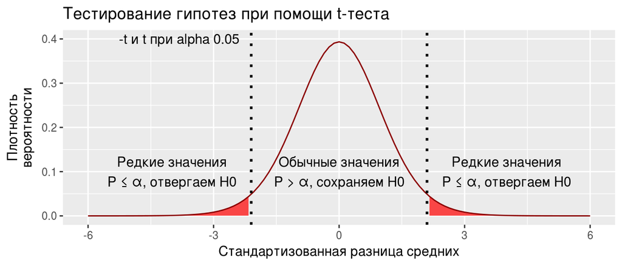

## Тестирование гипотезы о равенстве двух средних при помощи t-теста

### Алгоритм действий

1. Для конкретных данных считаем значение t-критерия
2. Сравниваем его с теоретическим распределением t (распределением при условии, что \(H_0\) верна) при данном числе степеней свободы df. Находим p — вероятность найти более экстремальное значение тестовой статистики.
3. Решаем, отвергнуть ли \(H_0\):
   - Если \(P \le \alpha\), отвергаем \(H_0\)
   - Если \(P > \alpha\), сохраняем \(H_0\)

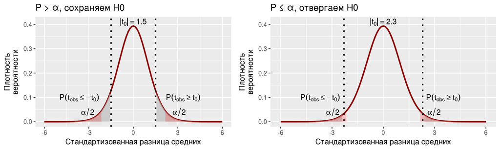

## Применение t-теста

## Пример: Снотворное

В датасете `sleep` содержатся данные об увеличении продолжительности сна по сравнению с контролем после применения двух снотворных препаратов (Cushny, Peebles, 1905, Student, 1908)

```r
data(sleep)
head(sleep)
```

```
##   extra group ID
## 1   0.7     1  1
## 2  -1.6     1  2
## 3  -0.2     1  3
## 4  -1.2     1  4
## 5  -0.1     1  5
## 6   3.4     1  6
```

```r
# str(sleep)
```

## Двухвыборочный t-критерий

Сравним увеличение продолжительности сна при помощи двухвыборочного t-критерия.

```r
tt <- t.test(extra ~ group, sleep)
tt
```

```
##
##  Welch Two Sample t-test
##
## data:  extra by group
## t = -2, df = 20, p-value = 0.08
## alternative hypothesis: true difference in means is not equal to 0
## 95 percent confidence interval:
##  -3.365  0.205
## sample estimates:
## mean in group 1 mean in group 2
##            0.75            2.33
```

Результаты можно описать, например, так:

- Различия изменения продолжительности сна при применении двух препаратов были недостоверны (\(t_{17.78} = -1.86\), \(p = 0.08\))

## Что спрятано в результатах?

Как называются отдельные элементы результатов можно узнать посмотрев их структуру при помощи функции `str()`

```r
str(tt)
```

```
## List of 9
##  $ statistic  : Named num -1.86
##   ..- attr(*, "names")= chr "t"
##  $ parameter  : Named num 17.8
##   ..- attr(*, "names")= chr "df"
##  $ p.value    : num 0.0794
##  $ conf.int   : atomic [1:2] -3.365 0.205
##   ..- attr(*, "conf.level")= num 0.95
##  $ estimate   : Named num [1:2] 0.75 2.33
##   ..- attr(*, "names")= chr [1:2] "mean in group 1" "mean in group 2"
##  $ null.value : Named num 0
##   ..- attr(*, "names")= chr "difference in means"
##  $ alternative: chr "two.sided"
##  $ method     : chr "Welch Two Sample t-test"
##  $ data.name  : chr "extra by group"
##  - attr(*, "class")= chr "htest"
```

## Можно получить элементы результатов в виде отдельных цифр

```r
tt$parameter # степени свободы
```

```
##   df
## 17.8
```

```r
tt$p.value # доверительная вероятность
```

```
## [1] 0.0794
```

```r
tt$statistic # значение t-критерия
```

```
##     t
## -1.86
```

## Задание

Файл `aml.csv` содержит данные о влиянии регулярной химиотерапии на продолжительность ремиссии.

Прочитаем эти данные

```r
rem <- read.csv(file = "data/aml.csv", header = TRUE)
str(rem)
```

```
## 'data.frame':    23 obs. of  2 variables:
##  $ time : int  9 13 13 18 23 28 31 34 45 48 ...
##  $ group: int  1 1 1 1 1 1 1 1 1 1 ...
```

- В переменной `time` представлена продолжительность ремиссии в днях.
- `group` указывает, к какой экспериментальной группе принадлежал пациент. В группе 1 проводилась регулярная химиотерапия, в группе 2 - нет.

Ваша задача сравнить эти группы с помощью t-теста.

## Решение

```r
t.test(data = rem, time ~ group)
```

```
##
##  Welch Two Sample t-test
##
## data:  time by group
## t = 1, df = 10, p-value = 0.2
## alternative hypothesis: true difference in means is not equal to 0
## 95 percent confidence interval:
##  -12.2  46.6
## sample estimates:
## mean in group 1 mean in group 2
##            38.5            21.2
```

Или так:

```r
t.test(rem$time[rem$group == 1], rem$time[rem$group == 2])
```

## Статистическая значимость

## Статистическая значимость

Статистическая значимость бывает только одна, и она говорит о том, в каких отношениях состоят, обнаруженные нами эмпирически различия с \(\alpha\).

- Если мы отвергаем \(H_0\) — значит, имеются различия
- Если мы не отвергаем \(H_0\) — значит, все одинаково

Пожалуйста, никаких "недостоверных различий"! Если различия есть, то они достоверны. Если различия не достоверны, то их нет.

А что делать, если сердцем чувствуешь, что что-то должно быть, но тест не дает нужного ответа? Собрать выборки побольше, и посчитать заново. С уже проведенным тестом спорить не надо.

## Take-home messages

- Стандартизация — преобразование данных в отклонения от среднего значения, измеренные в стандартных отклонениях
- Стандартное нормальное распределение удобно для расчетов вероятностей
- Вероятность попадания случайной величины в произвольный интервал можно получить в результате интегрирования кривой распределения на этом интервале
- При тестировании нулевой гипотезы оценивают вероятность получения данного или более экстремального значения тестовой статистики при условии справедливости нулевой гипотезы. Если эта вероятность меньше выбранного уровня значимости, то нулевую гипотезу отвергают
- Для сравнения выборочных средних в независимых выборках лучше использовать t-критерий Уэлча, который учитывает, что дисперсии в выборках могут быть разными

## Дополнительные ресурсы

- OpenIntro: Statistics
- Quinn, Keough, 2002
- Sokal, Rohlf, 1995
- Zar, 1999